# Risk Factor Analysis

## Outcome Variable

**Outcome Variable:** haz

## Predictor Variables

**Intervention Variable:** impsan

**Adjustment Set:**

- arm
- sex
- W_mage
- meducyrs
- feducyrs
- hhwealth_quart
- hfoodsec
- W_mhtcm
- W_mwtkg
- W_mbmi
- W_nrooms
- W_nchldlt5
- W_parity
- impfloor
- safeh20
- delta_W_mage
- delta_meducyrs
- delta_feducyrs
- delta_hhwealth_quart
- delta_hfoodsec
- delta_W_mhtcm
- delta_W_mwtkg
- delta_W_mbmi
- delta_W_nrooms
- delta_W_nchldlt5
- delta_W_parity
- delta_impfloor
- delta_safeh20

## Stratifying Variables

The analysis was stratified on these variable(s):

- agecat
- studyid
- country

## Data Summary

| agecat | studyid | country | impsan | n_cell | n | outcome_variable |
| --- | --- | --- | --- | --- | --- | --- |
| Birth | ki0047075b-MAL-ED | BANGLADESH | 1 | 179 | 213 | haz |
| Birth | ki0047075b-MAL-ED | BANGLADESH | 0 | 34 | 213 | haz |
| Birth | ki0047075b-MAL-ED | BRAZIL | 1 | 59 | 60 | haz |
| Birth | ki0047075b-MAL-ED | BRAZIL | 0 | 1 | 60 | haz |
| Birth | ki0047075b-MAL-ED | INDIA | 1 | 15 | 40 | haz |
| Birth | ki0047075b-MAL-ED | INDIA | 0 | 25 | 40 | haz |
| Birth | ki0047075b-MAL-ED | NEPAL | 1 | 25 | 26 | haz |
| Birth | ki0047075b-MAL-ED | NEPAL | 0 | 1 | 26 | haz |
| Birth | ki0047075b-MAL-ED | PERU | 1 | 52 | 208 | haz |
| Birth | ki0047075b-MAL-ED | PERU | 0 | 156 | 208 | haz |
| Birth | ki0047075b-MAL-ED | SOUTH AFRICA | 1 | 0 | 95 | haz |
| Birth | ki0047075b-MAL-ED | SOUTH AFRICA | 0 | 95 | 95 | haz |
| Birth | ki0047075b-MAL-ED | TANZANIA, UNITED REPUBLIC OF | 1 | 0 | 118 | haz |
| Birth | ki0047075b-MAL-ED | TANZANIA, UNITED REPUBLIC OF | 0 | 118 | 118 | haz |
| Birth | ki1017093-NIH-Birth | BANGLADESH | 1 | 231 | 608 | haz |
| Birth | ki1017093-NIH-Birth | BANGLADESH | 0 | 377 | 608 | haz |
| Birth | ki1017093b-PROVIDE | BANGLADESH | 1 | 43 | 45 | haz |
| Birth | ki1017093b-PROVIDE | BANGLADESH | 0 | 2 | 45 | haz |
| Birth | ki1017093c-NIH-Crypto | BANGLADESH | 1 | 632 | 721 | haz |
| Birth | ki1017093c-NIH-Crypto | BANGLADESH | 0 | 89 | 721 | haz |
| Birth | ki1114097-CONTENT | PERU | 1 | 1 | 2 | haz |
| Birth | ki1114097-CONTENT | PERU | 0 | 1 | 2 | haz |
| Birth | ki1135781-COHORTS | GUATEMALA | 1 | 45 | 491 | haz |
| Birth | ki1135781-COHORTS | GUATEMALA | 0 | 446 | 491 | haz |
| Birth | ki1135781-COHORTS | INDIA | 1 | 1767 | 4776 | haz |
| Birth | ki1135781-COHORTS | INDIA | 0 | 3009 | 4776 | haz |
| Birth | ki1135781-COHORTS | PHILIPPINES | 1 | 178 | 1191 | haz |
| Birth | ki1135781-COHORTS | PHILIPPINES | 0 | 1013 | 1191 | haz |
| Birth | kiGH5241-JiVitA-3 | BANGLADESH | 1 | 15220 | 22431 | haz |
| Birth | kiGH5241-JiVitA-3 | BANGLADESH | 0 | 7211 | 22431 | haz |

[output cut: 70 more lines]

The following strata were considered:

- agecat: 24 months, studyid: ki0047075b-MAL-ED, country: BANGLADESH
- agecat: 24 months, studyid: ki0047075b-MAL-ED, country: BRAZIL
- agecat: 24 months, studyid: ki0047075b-MAL-ED, country: INDIA
- agecat: 24 months, studyid: ki0047075b-MAL-ED, country: NEPAL
- agecat: 24 months, studyid: ki0047075b-MAL-ED, country: PERU
- agecat: 24 months, studyid: ki0047075b-MAL-ED, country: SOUTH AFRICA
- agecat: 24 months, studyid: ki0047075b-MAL-ED, country: TANZANIA, UNITED REPUBLIC OF
- agecat: 24 months, studyid: ki1017093-NIH-Birth, country: BANGLADESH
- agecat: 24 months, studyid: ki1017093b-PROVIDE, country: BANGLADESH
- agecat: 24 months, studyid: ki1017093c-NIH-Crypto, country: BANGLADESH
- agecat: 24 months, studyid: ki1114097-CONTENT, country: PERU
- agecat: 24 months, studyid: ki1135781-COHORTS, country: GUATEMALA
- agecat: 24 months, studyid: ki1135781-COHORTS, country: INDIA
- agecat: 24 months, studyid: ki1135781-COHORTS, country: PHILIPPINES
- agecat: 24 months, studyid: ki1148112-LCNI-5, country: MALAWI
- agecat: 24 months, studyid: kiGH5241-JiVitA-3, country: BANGLADESH
- agecat: 24 months, studyid: kiGH5241-JiVitA-4, country: BANGLADESH
- agecat: 6 months, studyid: ki0047075b-MAL-ED, country: BANGLADESH
- agecat: 6 months, studyid: ki0047075b-MAL-ED, country: BRAZIL
- agecat: 6 months, studyid: ki0047075b-MAL-ED, country: INDIA
- agecat: 6 months, studyid: ki0047075b-MAL-ED, country: NEPAL
- agecat: 6 months, studyid: ki0047075b-MAL-ED, country: PERU
- agecat: 6 months, studyid: ki0047075b-MAL-ED, country: SOUTH AFRICA
- agecat: 6 months, studyid: ki0047075b-MAL-ED, country: TANZANIA, UNITED REPUBLIC OF
- agecat: 6 months, studyid: ki1017093-NIH-Birth, country: BANGLADESH
- agecat: 6 months, studyid: ki1017093b-PROVIDE, country: BANGLADESH
- agecat: 6 months, studyid: ki1017093c-NIH-Crypto, country: BANGLADESH
- agecat: 6 months, studyid: ki1114097-CONTENT, country: PERU
- agecat: 6 months, studyid: ki1135781-COHORTS, country: GUATEMALA
- agecat: 6 months, studyid: ki1135781-COHORTS, country: INDIA
- agecat: 6 months, studyid: ki1135781-COHORTS, country: PHILIPPINES
- agecat: 6 months, studyid: ki1148112-LCNI-5, country: MALAWI
- agecat: 6 months, studyid: kiGH5241-JiVitA-3, country: BANGLADESH
- agecat: 6 months, studyid: kiGH5241-JiVitA-4, country: BANGLADESH
- agecat: Birth, studyid: ki0047075b-MAL-ED, country: BANGLADESH
- agecat: Birth, studyid: ki0047075b-MAL-ED, country: BRAZIL
- agecat: Birth, studyid: ki0047075b-MAL-ED, country: INDIA
- agecat: Birth, studyid: ki0047075b-MAL-ED, country: NEPAL
- agecat: Birth, studyid: ki0047075b-MAL-ED, country: PERU
- agecat: Birth, studyid: ki0047075b-MAL-ED, country: SOUTH AFRICA
- agecat: Birth, studyid: ki0047075b-MAL-ED, country: TANZANIA, UNITED REPUBLIC OF
- agecat: Birth, studyid: ki1017093-NIH-Birth, country: BANGLADESH
- agecat: Birth, studyid: ki1017093b-PROVIDE, country: BANGLADESH
- agecat: Birth, studyid: ki1017093c-NIH-Crypto, country: BANGLADESH
- agecat: Birth, studyid: ki1114097-CONTENT, country: PERU
- agecat: Birth, studyid: ki1135781-COHORTS, country: GUATEMALA
- agecat: Birth, studyid: ki1135781-COHORTS, country: INDIA
- agecat: Birth, studyid: ki1135781-COHORTS, country: PHILIPPINES
- agecat: Birth, studyid: kiGH5241-JiVitA-3, country: BANGLADESH
- agecat: Birth, studyid: kiGH5241-JiVitA-4, country: BANGLADESH

### Dropped Strata

Some strata were dropped due to rare outcomes:

- agecat: Birth, studyid: ki0047075b-MAL-ED, country: BRAZIL
- agecat: Birth, studyid: ki0047075b-MAL-ED, country: NEPAL
- agecat: Birth, studyid: ki0047075b-MAL-ED, country: SOUTH AFRICA
- agecat: Birth, studyid: ki0047075b-MAL-ED, country: TANZANIA, UNITED REPUBLIC OF
- agecat: Birth, studyid: ki1017093b-PROVIDE, country: BANGLADESH
- agecat: Birth, studyid: ki1114097-CONTENT, country: PERU
- agecat: 6 months, studyid: ki0047075b-MAL-ED, country: BRAZIL
- agecat: 6 months, studyid: ki0047075b-MAL-ED, country: NEPAL
- agecat: 6 months, studyid: ki0047075b-MAL-ED, country: SOUTH AFRICA
- agecat: 6 months, studyid: ki0047075b-MAL-ED, country: TANZANIA, UNITED REPUBLIC OF
- agecat: 6 months, studyid: ki1017093b-PROVIDE, country: BANGLADESH
- agecat: 6 months, studyid: ki1148112-LCNI-5, country: MALAWI
- agecat: 24 months, studyid: ki0047075b-MAL-ED, country: BRAZIL
- agecat: 24 months, studyid: ki0047075b-MAL-ED, country: NEPAL
- agecat: 24 months, studyid: ki0047075b-MAL-ED, country: SOUTH AFRICA
- agecat: 24 months, studyid: ki0047075b-MAL-ED, country: TANZANIA, UNITED REPUBLIC OF
- agecat: 24 months, studyid: ki1017093b-PROVIDE, country: BANGLADESH
- agecat: 24 months, studyid: ki1148112-LCNI-5, country: MALAWI

## Methods Detail

We’re interested in the causal parameters $E[Y_a]$ for all values of $a \in \mathcal{A}$. These parameters represent the mean outcome if, possibly contrary to fact, we intervened to set all units to have $A=a$. Under the randomization and positivity assumptions, these are identified by the statistical parameters $\psi_a=E_W[E_{Y|A,W}(Y|A=a,W)]$. In addition, we’re interested in the mean of $Y$, $E[Y]$ under no intervention (the observed mean). We will estimate these parameters by using SuperLearner to fit the relevant likelihood factors – $E_{Y|A,W}(Y|A=a,W)$ and $p(A=a|W)$, and then updating our likelihood fit using a joint TMLE.

For unadjusted analyses ($W=\{\}$), initial likelihoods were estimated using Lrnr_glm to estimate the simple $E(Y|A)$ and Lrnr_mean to estimate $p(A)$. For adjusted analyses, a small library containing Lrnr_glmnet, Lrnr_xgboost, and Lrnr_mean was used.

Having estimated these parameters, we will then use the delta method to estimate relative risks and attributable risks relative to a prespecified baseline level of $A$.

# Results Detail

## Results Plots

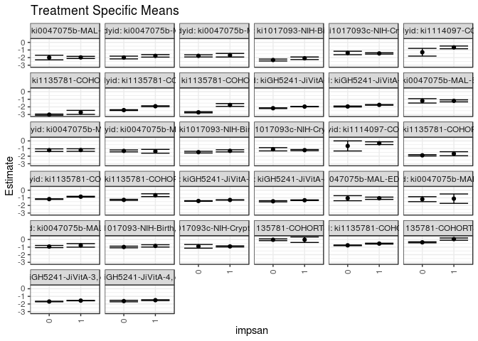

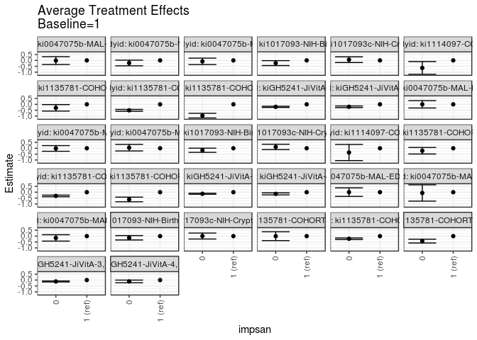

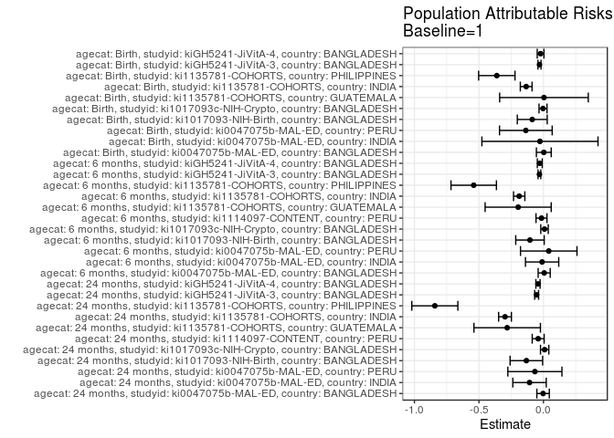

## Results Table

### Parameter: TSM

| agecat | studyid | country | intervention_level | baseline_level | estimate | ci_lower | ci_upper |
| --- | --- | --- | --- | --- | --- | --- | --- |
| Birth | ki0047075b-MAL-ED | BANGLADESH | 1 | NA | -1.0556498 | -1.2054804 | -0.9058192 |
| Birth | ki0047075b-MAL-ED | BANGLADESH | 0 | NA | -1.0510064 | -1.3822614 | -0.7197515 |
| Birth | ki0047075b-MAL-ED | INDIA | 1 | NA | -1.1102983 | -1.7255477 | -0.4950490 |
| Birth | ki0047075b-MAL-ED | INDIA | 0 | NA | -1.1756429 | -1.5000065 | -0.8512792 |
| Birth | ki0047075b-MAL-ED | PERU | 1 | NA | -0.7766497 | -1.0081213 | -0.5451781 |
| Birth | ki0047075b-MAL-ED | PERU | 0 | NA | -0.9281054 | -1.0710633 | -0.7851475 |
| Birth | ki1017093-NIH-Birth | BANGLADESH | 1 | NA | -0.8441904 | -0.9967016 | -0.6916792 |
| Birth | ki1017093-NIH-Birth | BANGLADESH | 0 | NA | -0.9850559 | -1.0932380 | -0.8768739 |
| Birth | ki1017093c-NIH-Crypto | BANGLADESH | 1 | NA | -0.9096449 | -0.9845841 | -0.8347057 |
| Birth | ki1017093c-NIH-Crypto | BANGLADESH | 0 | NA | -0.9021663 | -1.1426770 | -0.6616555 |
| Birth | ki1135781-COHORTS | GUATEMALA | 1 | NA | -0.0314971 | -0.3919709 | 0.3289767 |
| Birth | ki1135781-COHORTS | GUATEMALA | 0 | NA | -0.0367371 | -0.1504747 | 0.0770005 |
| Birth | ki1135781-COHORTS | INDIA | 1 | NA | -0.5439234 | -0.5997292 | -0.4881175 |
| Birth | ki1135781-COHORTS | INDIA | 0 | NA | -0.7685131 | -0.8111811 | -0.7258450 |
| Birth | ki1135781-COHORTS | PHILIPPINES | 1 | NA | 0.0477759 | -0.1000297 | 0.1955815 |
| Birth | ki1135781-COHORTS | PHILIPPINES | 0 | NA | -0.3742294 | -0.4429292 | -0.3055297 |
| Birth | kiGH5241-JiVitA-3 | BANGLADESH | 1 | NA | -1.5591658 | -1.5815613 | -1.5367703 |
| Birth | kiGH5241-JiVitA-3 | BANGLADESH | 0 | NA | -1.6779932 | -1.7134084 | -1.6425780 |
| Birth | kiGH5241-JiVitA-4 | BANGLADESH | 1 | NA | -1.5013364 | -1.5575992 | -1.4450736 |
| Birth | kiGH5241-JiVitA-4 | BANGLADESH | 0 | NA | -1.6175558 | -1.7158819 | -1.5192296 |
| 6 months | ki0047075b-MAL-ED | BANGLADESH | 1 | NA | -1.2083214 | -1.3417940 | -1.0748488 |
| 6 months | ki0047075b-MAL-ED | BANGLADESH | 0 | NA | -1.2074513 | -1.4929059 | -0.9219968 |
| 6 months | ki0047075b-MAL-ED | INDIA | 1 | NA | -1.1981349 | -1.3660435 | -1.0302264 |
| 6 months | ki0047075b-MAL-ED | INDIA | 0 | NA | -1.2142136 | -1.3854003 | -1.0430269 |
| 6 months | ki0047075b-MAL-ED | PERU | 1 | NA | -1.3606380 | -1.6090863 | -1.1121898 |
| 6 months | ki0047075b-MAL-ED | PERU | 0 | NA | -1.3102223 | -1.4367121 | -1.1837326 |
| 6 months | ki1017093-NIH-Birth | BANGLADESH | 1 | NA | -1.3028042 | -1.4439214 | -1.1616870 |
| 6 months | ki1017093-NIH-Birth | BANGLADESH | 0 | NA | -1.4730258 | -1.5845647 | -1.3614870 |
| 6 months | ki1017093c-NIH-Crypto | BANGLADESH | 1 | NA | -1.2112385 | -1.2874043 | -1.1350728 |
| 6 months | ki1017093c-NIH-Crypto | BANGLADESH | 0 | NA | -1.0981760 | -1.3128637 | -0.8834882 |
| 6 months | ki1114097-CONTENT | PERU | 1 | NA | -0.2985634 | -0.4784491 | -0.1186777 |
| 6 months | ki1114097-CONTENT | PERU | 0 | NA | -0.6584902 | -1.3205969 | 0.0036166 |
| 6 months | ki1135781-COHORTS | GUATEMALA | 1 | NA | -1.6828109 | -1.9464265 | -1.4191954 |
| 6 months | ki1135781-COHORTS | GUATEMALA | 0 | NA | -1.8916034 | -1.9790349 | -1.8041720 |
| 6 months | ki1135781-COHORTS | INDIA | 1 | NA | -0.8533495 | -0.9065777 | -0.8001213 |
| 6 months | ki1135781-COHORTS | INDIA | 0 | NA | -1.1687450 | -1.2100451 | -1.1274449 |
| 6 months | ki1135781-COHORTS | PHILIPPINES | 1 | NA | -0.6536097 | -0.8393873 | -0.4678321 |
| 6 months | ki1135781-COHORTS | PHILIPPINES | 0 | NA | -1.2711815 | -1.3417083 | -1.2006546 |
| 6 months | kiGH5241-JiVitA-3 | BANGLADESH | 1 | NA | -1.2823001 | -1.3078232 | -1.2567769 |
| 6 months | kiGH5241-JiVitA-3 | BANGLADESH | 0 | NA | -1.4156114 | -1.4545019 | -1.3767209 |
| 6 months | kiGH5241-JiVitA-4 | BANGLADESH | 1 | NA | -1.3155806 | -1.3573570 | -1.2738042 |
| 6 months | kiGH5241-JiVitA-4 | BANGLADESH | 0 | NA | -1.4574769 | -1.5341546 | -1.3807992 |
| 24 months | ki0047075b-MAL-ED | BANGLADESH | 1 | NA | -1.9754701 | -2.1152837 | -1.8356565 |
| 24 months | ki0047075b-MAL-ED | BANGLADESH | 0 | NA | -1.9927902 | -2.2970475 | -1.6885328 |
| 24 months | ki0047075b-MAL-ED | INDIA | 1 | NA | -1.7700681 | -1.9334595 | -1.6066768 |
| 24 months | ki0047075b-MAL-ED | INDIA | 0 | NA | -1.9893711 | -2.1687091 | -1.8100330 |
| 24 months | ki0047075b-MAL-ED | PERU | 1 | NA | -1.6870195 | -1.9243721 | -1.4496669 |
| 24 months | ki0047075b-MAL-ED | PERU | 0 | NA | -1.7695368 | -1.9120033 | -1.6270703 |
| 24 months | ki1017093-NIH-Birth | BANGLADESH | 1 | NA | -2.0865773 | -2.2564557 | -1.9166988 |
| 24 months | ki1017093-NIH-Birth | BANGLADESH | 0 | NA | -2.3167904 | -2.4415188 | -2.1920619 |
| 24 months | ki1017093c-NIH-Crypto | BANGLADESH | 1 | NA | -1.4509848 | -1.5425282 | -1.3594413 |
| 24 months | ki1017093c-NIH-Crypto | BANGLADESH | 0 | NA | -1.3895592 | -1.6151877 | -1.1639308 |
| 24 months | ki1114097-CONTENT | PERU | 1 | NA | -0.6552624 | -0.8348617 | -0.4756632 |
| 24 months | ki1114097-CONTENT | PERU | 0 | NA | -1.2948669 | -1.8039137 | -0.7858200 |
| 24 months | ki1135781-COHORTS | GUATEMALA | 1 | NA | -2.7238849 | -2.9895244 | -2.4582453 |
| 24 months | ki1135781-COHORTS | GUATEMALA | 0 | NA | -3.0221427 | -3.0961678 | -2.9481176 |
| 24 months | ki1135781-COHORTS | INDIA | 1 | NA | -1.9146893 | -1.9755068 | -1.8538719 |
| 24 months | ki1135781-COHORTS | INDIA | 0 | NA | -2.4236893 | -2.4747596 | -2.3726191 |
| 24 months | ki1135781-COHORTS | PHILIPPINES | 1 | NA | -1.7517888 | -1.9365065 | -1.5670711 |
| 24 months | ki1135781-COHORTS | PHILIPPINES | 0 | NA | -2.7136730 | -2.7856368 | -2.6417092 |
| 24 months | kiGH5241-JiVitA-3 | BANGLADESH | 1 | NA | -1.9607554 | -1.9921040 | -1.9294068 |
| 24 months | kiGH5241-JiVitA-3 | BANGLADESH | 0 | NA | -2.1736894 | -2.2214131 | -2.1259656 |
| 24 months | kiGH5241-JiVitA-4 | BANGLADESH | 1 | NA | -1.7378817 | -1.7786012 | -1.6971622 |
| 24 months | kiGH5241-JiVitA-4 | BANGLADESH | 0 | NA | -1.9463158 | -2.0069917 | -1.8856398 |

### Parameter: E(Y)

| agecat | studyid | country | intervention_level | baseline_level | estimate | ci_lower | ci_upper |
| --- | --- | --- | --- | --- | --- | --- | --- |
| Birth | ki0047075b-MAL-ED | BANGLADESH | NA | NA | -1.0530516 | -1.1896058 | -0.9164975 |
| Birth | ki0047075b-MAL-ED | INDIA | NA | NA | -1.1375000 | -1.4325178 | -0.8424822 |
| Birth | ki0047075b-MAL-ED | PERU | NA | NA | -0.9131731 | -1.0331160 | -0.7932301 |
| Birth | ki1017093-NIH-Birth | BANGLADESH | NA | NA | -0.9310197 | -1.0197391 | -0.8423003 |
| Birth | ki1017093c-NIH-Crypto | BANGLADESH | NA | NA | -0.9131068 | -0.9851939 | -0.8410197 |
| Birth | ki1135781-COHORTS | GUATEMALA | NA | NA | -0.0275356 | -0.1359303 | 0.0808590 |
| Birth | ki1135781-COHORTS | INDIA | NA | NA | -0.6777115 | -0.7106054 | -0.6448175 |
| Birth | ki1135781-COHORTS | PHILIPPINES | NA | NA | -0.3137364 | -0.3764483 | -0.2510244 |
| Birth | kiGH5241-JiVitA-3 | BANGLADESH | NA | NA | -1.5898288 | -1.6090823 | -1.5705753 |
| Birth | kiGH5241-JiVitA-4 | BANGLADESH | NA | NA | -1.5236135 | -1.5727559 | -1.4744711 |
| 6 months | ki0047075b-MAL-ED | BANGLADESH | NA | NA | -1.2026806 | -1.3203025 | -1.0850586 |
| 6 months | ki0047075b-MAL-ED | INDIA | NA | NA | -1.2087268 | -1.3282418 | -1.0892117 |
| 6 months | ki0047075b-MAL-ED | PERU | NA | NA | -1.3196229 | -1.4293681 | -1.2098778 |
| 6 months | ki1017093-NIH-Birth | BANGLADESH | NA | NA | -1.4073821 | -1.4960598 | -1.3187043 |
| 6 months | ki1017093c-NIH-Crypto | BANGLADESH | NA | NA | -1.2031037 | -1.2749632 | -1.1312442 |
| 6 months | ki1114097-CONTENT | PERU | NA | NA | -0.3139217 | -0.4868486 | -0.1409948 |
| 6 months | ki1135781-COHORTS | GUATEMALA | NA | NA | -1.8789210 | -1.9609921 | -1.7968498 |
| 6 months | ki1135781-COHORTS | INDIA | NA | NA | -1.0414424 | -1.0741113 | -1.0087734 |
| 6 months | ki1135781-COHORTS | PHILIPPINES | NA | NA | -1.1942936 | -1.2608624 | -1.1277248 |
| 6 months | kiGH5241-JiVitA-3 | BANGLADESH | NA | NA | -1.3134804 | -1.3366079 | -1.2903528 |
| 6 months | kiGH5241-JiVitA-4 | BANGLADESH | NA | NA | -1.3440477 | -1.3813060 | -1.3067894 |
| 24 months | ki0047075b-MAL-ED | BANGLADESH | NA | NA | -1.9783962 | -2.1050210 | -1.8517715 |
| 24 months | ki0047075b-MAL-ED | INDIA | NA | NA | -1.8779556 | -2.0033207 | -1.7525904 |
| 24 months | ki0047075b-MAL-ED | PERU | NA | NA | -1.7535204 | -1.8760973 | -1.6309435 |
| 24 months | ki1017093-NIH-Birth | BANGLADESH | NA | NA | -2.2190579 | -2.3217459 | -2.1163699 |
| 24 months | ki1017093c-NIH-Crypto | BANGLADESH | NA | NA | -1.4417097 | -1.5263855 | -1.3570340 |
| 24 months | ki1114097-CONTENT | PERU | NA | NA | -0.6962195 | -0.8674103 | -0.5250287 |
| 24 months | ki1135781-COHORTS | GUATEMALA | NA | NA | -3.0050840 | -3.0758338 | -2.9343342 |
| 24 months | ki1135781-COHORTS | INDIA | NA | NA | -2.2126633 | -2.2518337 | -2.1734929 |
| 24 months | ki1135781-COHORTS | PHILIPPINES | NA | NA | -2.5937576 | -2.6629996 | -2.5245156 |
| 24 months | kiGH5241-JiVitA-3 | BANGLADESH | NA | NA | -2.0136975 | -2.0413718 | -1.9860232 |
| 24 months | kiGH5241-JiVitA-4 | BANGLADESH | NA | NA | -1.7803708 | -1.8158650 | -1.7448765 |

### Parameter: ATE

| agecat | studyid | country | intervention_level | baseline_level | estimate | ci_lower | ci_upper |
| --- | --- | --- | --- | --- | --- | --- | --- |
| Birth | ki0047075b-MAL-ED | BANGLADESH | 1 | 1 | 0.0000000 | 0.0000000 | 0.0000000 |
| Birth | ki0047075b-MAL-ED | BANGLADESH | 0 | 1 | 0.0046434 | -0.3593233 | 0.3686101 |
| Birth | ki0047075b-MAL-ED | INDIA | 1 | 1 | 0.0000000 | 0.0000000 | 0.0000000 |
| Birth | ki0047075b-MAL-ED | INDIA | 0 | 1 | -0.0653445 | -0.7593070 | 0.6286180 |
| Birth | ki0047075b-MAL-ED | PERU | 1 | 1 | 0.0000000 | 0.0000000 | 0.0000000 |
| Birth | ki0047075b-MAL-ED | PERU | 0 | 1 | -0.1514557 | -0.4206284 | 0.1177170 |
| Birth | ki1017093-NIH-Birth | BANGLADESH | 1 | 1 | 0.0000000 | 0.0000000 | 0.0000000 |
| Birth | ki1017093-NIH-Birth | BANGLADESH | 0 | 1 | -0.1408655 | -0.3270501 | 0.0453191 |
| Birth | ki1017093c-NIH-Crypto | BANGLADESH | 1 | 1 | 0.0000000 | 0.0000000 | 0.0000000 |
| Birth | ki1017093c-NIH-Crypto | BANGLADESH | 0 | 1 | 0.0074786 | -0.2440856 | 0.2590428 |
| Birth | ki1135781-COHORTS | GUATEMALA | 1 | 1 | 0.0000000 | 0.0000000 | 0.0000000 |
| Birth | ki1135781-COHORTS | GUATEMALA | 0 | 1 | -0.0052400 | -0.3828781 | 0.3723980 |
| Birth | ki1135781-COHORTS | INDIA | 1 | 1 | 0.0000000 | 0.0000000 | 0.0000000 |
| Birth | ki1135781-COHORTS | INDIA | 0 | 1 | -0.2245897 | -0.2945168 | -0.1546626 |
| Birth | ki1135781-COHORTS | PHILIPPINES | 1 | 1 | 0.0000000 | 0.0000000 | 0.0000000 |
| Birth | ki1135781-COHORTS | PHILIPPINES | 0 | 1 | -0.4220053 | -0.5843808 | -0.2596298 |
| Birth | kiGH5241-JiVitA-3 | BANGLADESH | 1 | 1 | 0.0000000 | 0.0000000 | 0.0000000 |
| Birth | kiGH5241-JiVitA-3 | BANGLADESH | 0 | 1 | -0.1188274 | -0.1574543 | -0.0802004 |
| Birth | kiGH5241-JiVitA-4 | BANGLADESH | 1 | 1 | 0.0000000 | 0.0000000 | 0.0000000 |
| Birth | kiGH5241-JiVitA-4 | BANGLADESH | 0 | 1 | -0.1162194 | -0.2281798 | -0.0042589 |
| 6 months | ki0047075b-MAL-ED | BANGLADESH | 1 | 1 | 0.0000000 | 0.0000000 | 0.0000000 |
| 6 months | ki0047075b-MAL-ED | BANGLADESH | 0 | 1 | 0.0008701 | -0.3146790 | 0.3164192 |
| 6 months | ki0047075b-MAL-ED | INDIA | 1 | 1 | 0.0000000 | 0.0000000 | 0.0000000 |
| 6 months | ki0047075b-MAL-ED | INDIA | 0 | 1 | -0.0160787 | -0.2564922 | 0.2243349 |
| 6 months | ki0047075b-MAL-ED | PERU | 1 | 1 | 0.0000000 | 0.0000000 | 0.0000000 |
| 6 months | ki0047075b-MAL-ED | PERU | 0 | 1 | 0.0504157 | -0.2285030 | 0.3293344 |
| 6 months | ki1017093-NIH-Birth | BANGLADESH | 1 | 1 | 0.0000000 | 0.0000000 | 0.0000000 |
| 6 months | ki1017093-NIH-Birth | BANGLADESH | 0 | 1 | -0.1702216 | -0.3481352 | 0.0076919 |
| 6 months | ki1017093c-NIH-Crypto | BANGLADESH | 1 | 1 | 0.0000000 | 0.0000000 | 0.0000000 |
| 6 months | ki1017093c-NIH-Crypto | BANGLADESH | 0 | 1 | 0.1130626 | -0.1147017 | 0.3408269 |
| 6 months | ki1114097-CONTENT | PERU | 1 | 1 | 0.0000000 | 0.0000000 | 0.0000000 |
| 6 months | ki1114097-CONTENT | PERU | 0 | 1 | -0.3599268 | -1.0456704 | 0.3258168 |
| 6 months | ki1135781-COHORTS | GUATEMALA | 1 | 1 | 0.0000000 | 0.0000000 | 0.0000000 |
| 6 months | ki1135781-COHORTS | GUATEMALA | 0 | 1 | -0.2087925 | -0.4867210 | 0.0691360 |
| 6 months | ki1135781-COHORTS | INDIA | 1 | 1 | 0.0000000 | 0.0000000 | 0.0000000 |
| 6 months | ki1135781-COHORTS | INDIA | 0 | 1 | -0.3153955 | -0.3820284 | -0.2487626 |
| 6 months | ki1135781-COHORTS | PHILIPPINES | 1 | 1 | 0.0000000 | 0.0000000 | 0.0000000 |
| 6 months | ki1135781-COHORTS | PHILIPPINES | 0 | 1 | -0.6175717 | -0.8166637 | -0.4184798 |
| 6 months | kiGH5241-JiVitA-3 | BANGLADESH | 1 | 1 | 0.0000000 | 0.0000000 | 0.0000000 |
| 6 months | kiGH5241-JiVitA-3 | BANGLADESH | 0 | 1 | -0.1333113 | -0.1736773 | -0.0929453 |
| 6 months | kiGH5241-JiVitA-4 | BANGLADESH | 1 | 1 | 0.0000000 | 0.0000000 | 0.0000000 |
| 6 months | kiGH5241-JiVitA-4 | BANGLADESH | 0 | 1 | -0.1418963 | -0.2280017 | -0.0557909 |
| 24 months | ki0047075b-MAL-ED | BANGLADESH | 1 | 1 | 0.0000000 | 0.0000000 | 0.0000000 |
| 24 months | ki0047075b-MAL-ED | BANGLADESH | 0 | 1 | -0.0173201 | -0.3528267 | 0.3181866 |
| 24 months | ki0047075b-MAL-ED | INDIA | 1 | 1 | 0.0000000 | 0.0000000 | 0.0000000 |
| 24 months | ki0047075b-MAL-ED | INDIA | 0 | 1 | -0.2193029 | -0.4608425 | 0.0222366 |
| 24 months | ki0047075b-MAL-ED | PERU | 1 | 1 | 0.0000000 | 0.0000000 | 0.0000000 |
| 24 months | ki0047075b-MAL-ED | PERU | 0 | 1 | -0.0825173 | -0.3554745 | 0.1904399 |
| 24 months | ki1017093-NIH-Birth | BANGLADESH | 1 | 1 | 0.0000000 | 0.0000000 | 0.0000000 |
| 24 months | ki1017093-NIH-Birth | BANGLADESH | 0 | 1 | -0.2302131 | -0.4380083 | -0.0224179 |
| 24 months | ki1017093c-NIH-Crypto | BANGLADESH | 1 | 1 | 0.0000000 | 0.0000000 | 0.0000000 |
| 24 months | ki1017093c-NIH-Crypto | BANGLADESH | 0 | 1 | 0.0614256 | -0.1818401 | 0.3046913 |
| 24 months | ki1114097-CONTENT | PERU | 1 | 1 | 0.0000000 | 0.0000000 | 0.0000000 |
| 24 months | ki1114097-CONTENT | PERU | 0 | 1 | -0.6396044 | -1.1784271 | -0.1007817 |
| 24 months | ki1135781-COHORTS | GUATEMALA | 1 | 1 | 0.0000000 | 0.0000000 | 0.0000000 |
| 24 months | ki1135781-COHORTS | GUATEMALA | 0 | 1 | -0.2982578 | -0.5737317 | -0.0227839 |
| 24 months | ki1135781-COHORTS | INDIA | 1 | 1 | 0.0000000 | 0.0000000 | 0.0000000 |
| 24 months | ki1135781-COHORTS | INDIA | 0 | 1 | -0.5090000 | -0.5884750 | -0.4295250 |
| 24 months | ki1135781-COHORTS | PHILIPPINES | 1 | 1 | 0.0000000 | 0.0000000 | 0.0000000 |
| 24 months | ki1135781-COHORTS | PHILIPPINES | 0 | 1 | -0.9618842 | -1.1602263 | -0.7635422 |
| 24 months | kiGH5241-JiVitA-3 | BANGLADESH | 1 | 1 | 0.0000000 | 0.0000000 | 0.0000000 |
| 24 months | kiGH5241-JiVitA-3 | BANGLADESH | 0 | 1 | -0.2129340 | -0.2645225 | -0.1613454 |
| 24 months | kiGH5241-JiVitA-4 | BANGLADESH | 1 | 1 | 0.0000000 | 0.0000000 | 0.0000000 |
| 24 months | kiGH5241-JiVitA-4 | BANGLADESH | 0 | 1 | -0.2084340 | -0.2798707 | -0.1369974 |

### Parameter: PAR

| agecat | studyid | country | intervention_level | baseline_level | estimate | ci_lower | ci_upper |
| --- | --- | --- | --- | --- | --- | --- | --- |
| Birth | ki0047075b-MAL-ED | BANGLADESH | 1 | NA | 0.0025982 | -0.0547423 | 0.0599387 |
| Birth | ki0047075b-MAL-ED | INDIA | 1 | NA | -0.0272017 | -0.4772947 | 0.4228914 |
| Birth | ki0047075b-MAL-ED | PERU | 1 | NA | -0.1365234 | -0.3406661 | 0.0676193 |
| Birth | ki1017093-NIH-Birth | BANGLADESH | 1 | NA | -0.0868293 | -0.2027434 | 0.0290848 |
| Birth | ki1017093c-NIH-Crypto | BANGLADESH | 1 | NA | -0.0034619 | -0.0343677 | 0.0274439 |
| Birth | ki1135781-COHORTS | GUATEMALA | 1 | NA | 0.0039615 | -0.3395655 | 0.3474884 |
| Birth | ki1135781-COHORTS | INDIA | 1 | NA | -0.1337881 | -0.1793788 | -0.0881974 |
| Birth | ki1135781-COHORTS | PHILIPPINES | 1 | NA | -0.3615122 | -0.5024193 | -0.2206052 |
| Birth | kiGH5241-JiVitA-3 | BANGLADESH | 1 | NA | -0.0306630 | -0.0425026 | -0.0188235 |
| Birth | kiGH5241-JiVitA-4 | BANGLADESH | 1 | NA | -0.0222771 | -0.0482822 | 0.0037281 |
| 6 months | ki0047075b-MAL-ED | BANGLADESH | 1 | NA | 0.0056409 | -0.0410501 | 0.0523319 |
| 6 months | ki0047075b-MAL-ED | INDIA | 1 | NA | -0.0105918 | -0.1395496 | 0.1183660 |
| 6 months | ki0047075b-MAL-ED | PERU | 1 | NA | 0.0410151 | -0.1779373 | 0.2599675 |
| 6 months | ki1017093-NIH-Birth | BANGLADESH | 1 | NA | -0.1045779 | -0.2149367 | 0.0057810 |
| 6 months | ki1017093c-NIH-Crypto | BANGLADESH | 1 | NA | 0.0081349 | -0.0207834 | 0.0370531 |
| 6 months | ki1114097-CONTENT | PERU | 1 | NA | -0.0153583 | -0.0578276 | 0.0271110 |
| 6 months | ki1135781-COHORTS | GUATEMALA | 1 | NA | -0.1961100 | -0.4522307 | 0.0600107 |
| 6 months | ki1135781-COHORTS | INDIA | 1 | NA | -0.1880929 | -0.2319191 | -0.1442666 |
| 6 months | ki1135781-COHORTS | PHILIPPINES | 1 | NA | -0.5406839 | -0.7167844 | -0.3645834 |
| 6 months | kiGH5241-JiVitA-3 | BANGLADESH | 1 | NA | -0.0311803 | -0.0419169 | -0.0204437 |
| 6 months | kiGH5241-JiVitA-4 | BANGLADESH | 1 | NA | -0.0284671 | -0.0475815 | -0.0093526 |
| 24 months | ki0047075b-MAL-ED | BANGLADESH | 1 | NA | -0.0029261 | -0.0511490 | 0.0452968 |
| 24 months | ki0047075b-MAL-ED | INDIA | 1 | NA | -0.1078874 | -0.2372814 | 0.0215065 |
| 24 months | ki0047075b-MAL-ED | PERU | 1 | NA | -0.0665009 | -0.2761235 | 0.1431216 |
| 24 months | ki1017093-NIH-Birth | BANGLADESH | 1 | NA | -0.1324806 | -0.2585902 | -0.0063711 |
| 24 months | ki1017093c-NIH-Crypto | BANGLADESH | 1 | NA | 0.0092750 | -0.0229158 | 0.0414658 |
| 24 months | ki1114097-CONTENT | PERU | 1 | NA | -0.0409571 | -0.0872204 | 0.0053062 |
| 24 months | ki1135781-COHORTS | GUATEMALA | 1 | NA | -0.2811991 | -0.5389831 | -0.0234151 |
| 24 months | ki1135781-COHORTS | INDIA | 1 | NA | -0.2979739 | -0.3475045 | -0.2484434 |
| 24 months | ki1135781-COHORTS | PHILIPPINES | 1 | NA | -0.8419688 | -1.0203934 | -0.6635441 |
| 24 months | kiGH5241-JiVitA-3 | BANGLADESH | 1 | NA | -0.0529421 | -0.0680215 | -0.0378628 |
| 24 months | kiGH5241-JiVitA-4 | BANGLADESH | 1 | NA | -0.0424890 | -0.0588297 | -0.0261484 |